# Sta112FS 9. Multiple regression, interaction effects, and model selection

September 24, 2015

## Today's agenda

## Today's agenda

- Review App Ex from last time
  - Recap modeling with logged response variable
- Multiple linear regression
  - So you can explain more of the variability in the response variable
- Interaction variables
  - So you can start building models that better reflect reality
- Model selection
  - So you can decide on the best model(s)
- **Due Tuesday:**
  - App Ex 5: Requires consultation with Sandra

## Initial setup

## Load packages & data + data fixes

Load packages:

```r
library(ggplot2)
library(dplyr)
library(stringr)
```

Load data:

```r
pp <- read.csv("paris_paintings.csv", stringsAsFactors = FALSE) %>%
  tbl_df()
```

Fix prices:

```r
pp <- pp %>%
  mutate(price = as.numeric(str_replace(price, ",", "")))
```

## More data fixes

Fix shape coding:

```r
pp <- pp %>%
  mutate(shape_recode = ifelse(Shape == "", NA,
                               ifelse(Shape == "ovale", "oval",
                                      ifelse(Shape == "ronde", "round",
                                             ifelse(Shape == "octogon", "octagon", Shape)))))
```

Fix material coding:

```r
pp <- pp %>%
  mutate(mat_recode = ifelse(mat %in% c("a", "bc", "c"), "metal",
                             ifelse(mat %in% c("al", "ar", "m"), "stone",
                                    ifelse(mat %in% c("co", "bt", "t"), "canvas",
                                           ifelse(mat %in% c("p", "ca"), "paper",
                                                  ifelse(mat %in% c("b"), "wood",
                                                         ifelse(mat %in% c("o", "e", "v"), "other",
                                                                ifelse(mat %in% c("n/a", ""), NA,
                                                                       "uncertain"))))))))
```

## Multiple linear regression

## From last time…

The linear model with multiple predictors

- Population model: \[ \hat{y} = \beta_0 + \beta_1~x_1 + \beta_2~x_2 + \cdots + \beta_k~x_k \]
- Sample model that we use to estimate the population model: \[ \hat{y} = b_0 + b_1~x_1 + b_2~x_2 + \cdots + b_k~x_k \]

## Main effects

## Price, surface, and living artist

Very few paintings withs `Surface >= 5000`:

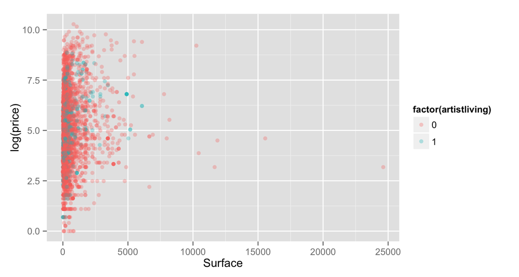

## Price, surface, and living artist

For simplicity let's focus on the paintings with `Surface < 5000`:

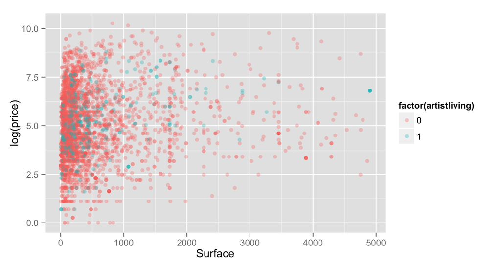

## Price vs. surface and living artist

Does the relationship between surface and logged price vary by whether or not the artist is living?

```r
ggplot(data = pp_Surf_lt_5000,
       aes(y = log(price), x = Surface, color = factor(artistliving))) +
  geom_point(alpha = 0.3) +
  stat_smooth(method = "lm", fullrange = TRUE)
```

[output not shown]

## Modeling with main effects

```r
(m_main <- lm(log(price) ~ Surface + factor(artistliving), data = pp_Surf_lt_5000))
```

```
##
## Call:
## lm(formula = log(price) ~ Surface + factor(artistliving), data = pp_Surf_lt_5000)
##
## Coefficients:
##           (Intercept)                Surface  factor(artistliving)1
##             4.8800835              0.0002653              0.1372103
```

- Plug in 0 for `artistliving` to get the linear model for paintings by non-living artists.
- Plug in 1 for `artistliving` to get the linear model for paintings by living artists.

## Interpretation of main effects

[figure not shown]

## Interaction effects

## Interacting explanatory variables

- Including an interaction effect in the model allows for different slopes, i.e. nonparallel lines.
- This implies that the regression coefficient for an explanatory variable would change as another explanatory variable changes.
- This can be accomplished by adding an interaction variable: the product of two explanatory variables.

## Price vs. surface and artist living interacting

```r
ggplot(data = pp_Surf_lt_5000,
       aes(y = log(price), x = Surface, color = factor(artistliving))) +
  geom_point(alpha = 0.3) +
  stat_smooth(method = "lm", fullrange = TRUE)
```

[output not shown]

## Modeling with interaction effects

```r
(m_int <- lm(log(price) ~ Surface * factor(artistliving), data = pp_Surf_lt_5000))
```

```
##
## Call:
## lm(formula = log(price) ~ Surface * factor(artistliving), data = pp_Surf_lt_5000)
##
## Coefficients:
##                   (Intercept)                        Surface
##                     4.9141894                      0.0002059
##         factor(artistliving)1  Surface:factor(artistliving)1
##                    -0.1261225                      0.0004792
```

\[\widehat{log(price)} = 4.91 + 0.00021~surface - 0.126~artistliving + 0.00048~surface \times artistliving \]

## Interpretation of interaction effects

- Non-living artist: \(\widehat{log(price)} = 4.91 + 0.00021~surface\) \(- 0.126 \times 0 + 0.00048~surface \times 0\) \(= 4.91 + 0.00021~surface\)
- Living artist: \(\widehat{log(price)} = 4.91 + 0.00021~surface\) \(- 0.126 \times 1 + 0.00048~surface \times 1\) \(= 4.91 + 0.00021~surface\) \(- 0.126 + 0.00048~surface\) \(= 4.784 + 0.00069~surface\)
- Rate of change in price as the surface area of the painting increases does vary between paintings by living and non-living artists (different slopes),
- Some paintings by living artists are more expensive than paintings by non-living artists, and some are not (different intercept).

## Third order interactions

- Can you? Yes
- Should you? Probably not if you want to interpret these interactions in context of the data.

## Quality of fit in MLR

## \(R^2\)

- \(R^2\) is the percentage of variability in the response variable explained by the regression model.

```r
summary(m_main)$r.squared
```

```
## [1] 0.01320884
```

```r
summary(m_int)$r.squared
```

```
## [1] 0.0176922
```

- Clearly the model with interactions has a higher \(R^2\).
- However using \(R^2\) for model selection in models with multiple explanatory variables is not a good idea as \(R^2\) increases when **any** variable is added to the model.

## \(R^2\) - first principles

\[ R^2 = \frac{ SS_{Reg} }{ SS_{Total} } = 1 - \left( \frac{ SS_{Error} }{ SS_{Total} } \right) \]

```r
anova(m_main)
```

```
## Analysis of Variance Table
##
## Response: log(price)
##                        Df  Sum Sq Mean Sq F value    Pr(>F)
## Surface                 1   138.5 138.537 40.6741 2.058e-10 ***
## factor(artistliving)    1     6.8   6.810  1.9994    0.1575
## Residuals            3188 10858.4   3.406
## ---
## Signif. codes:  0 '***' 0.001 '**' 0.01 '*' 0.05 '.' 0.1 ' ' 1
```

\[ R^2_{m\_main} = \frac{138.5 + 6.8}{138.5 + 6.8 + 10858.4} = \frac{145.3}{11003.7} \approx 0.013 \]

## \(R^2\) - first principles

\[ R^2 = \frac{ SS_{Reg} }{ SS_{Total} } = 1 - \left( \frac{ SS_{Error} }{ SS_{Total} } \right) \]

```r
anova(m_int)
```

```
## Analysis of Variance Table
##
## Response: log(price)
##                                Df  Sum Sq Mean Sq F value    Pr(>F)
## Surface                         1   138.5 138.537 40.8469 1.886e-10 ***
## factor(artistliving)            1     6.8   6.810  2.0079 0.1565836
## Surface:factor(artistliving)    1    49.3  49.334 14.5458 0.0001394 ***
## Residuals                    3187 10809.1   3.392
## ---
## Signif. codes:  0 '***' 0.001 '**' 0.01 '*' 0.05 '.' 0.1 ' ' 1
```

\[ R^2_{m\_int} = \frac{138.5 + 6.8 + 49.3}{138.5 + 6.8 + 49.3 + 10809.1} = \frac{194.6}{11003.7} \approx 0.018 \]

## Adjusted \(R^2\)

\[ R^2_{adj} = 1 - \left( \frac{ SS_{Error} }{ SS_{Total} } \times \frac{n - 1}{n - k - 1} \right) \] where \(n\) is the number of cases and \(k\) is the number of predictors in the model

- Adjusted \(R^2\) doesn't increase if the new variable does not provide any new informaton or is completely unrelated.
- This makes adjusted \(R^2\) a preferable metric for model selection in multiple regression models.

## In pursuit of Occam's Razor

- Occam's Razor states that among competing hypotheses that predict equally well, the one with the fewest assumptions should be selected.
- Model selection follows this principle.
- We only want to add another variable to the model if the addition of that variable brings something valuable in terms of predictive power to the model.
- In other words, we prefer the simplest best model, i.e. **parsimonious** model.

## Comparing models

It appears that adding the interaction actually increased adjusted \(R^2\), so we should indeed use the model with the interactions.

```r
summary(m_main)$adj.r.squared
```

```
## [1] 0.01258977
```

```r
summary(m_int)$adj.r.squared
```

```
## [1] 0.01676753
```

## Model selection methods

## Backwards elimination

- Start with **full** model (including all candidate explanatory variables and all candidate interactions)
- Remove one variable at a time, and select the model with the highest adjusted \(R^2\)
- Continue until adjusted \(R^2\) does not increase

## Forward selection

- Start with **empty** model
- Add one variable (or interaction effect) at a time, and select the model with the highest adjusted \(R^2\)
- Continue until adjusted \(R^2\) does not increase

## Model selection and interaction effects

If an interaction is included in the model, the main effects of both of those variables must also be in the model

## Other model selection criteria

- Adjusted \(R^2\) is one model selection criterion
- There are others out there (many many others!), we'll discuss some later in the course, and some you might see in another course

## Application Exercise

## App Ex 5

See course website.